# HT4

# Creacion de la variable categorica PriceType

```python
# Calcular los percentiles 33 y 66
p33 = datos_limpiados2['SalePrice'].quantile(0.33)
p66 = datos_limpiados2['SalePrice'].quantile(0.66)

# Crear la nueva variable categórica
def categorizar_precio(precio):
    if precio <= p33:
        return 'Economicas'
    elif precio <= p66:
        return 'Intermedias'
    else:
        return 'Caras'

# Aplicar la función al dataframe
datos_limpiados2['PriceType'] = datos_limpiados2['SalePrice'].apply(categorizar_precio)

print(datos_limpiados2[['SalePrice', 'PriceType']])
print('Percentil 33: ', p33, 'Percentil 66: ', p66 )
```

```
      SalePrice    PriceType
0        208500        Caras
1        181500  Intermedias
2        223500        Caras
3        140000  Intermedias
4        250000        Caras
...         ...          ...
1455     175000  Intermedias
1456     210000        Caras
1457     266500        Caras
1458     142125  Intermedias
1459     147500  Intermedias

[1460 rows x 2 columns]
Percentil 33:  139000.0 Percentil 66:  189893.00000000006
```

```python
datos_limpiados2.groupby('PriceType').size()
```

```
PriceType
Caras          497
Economicas     483
Intermedias    480
dtype: int64
```

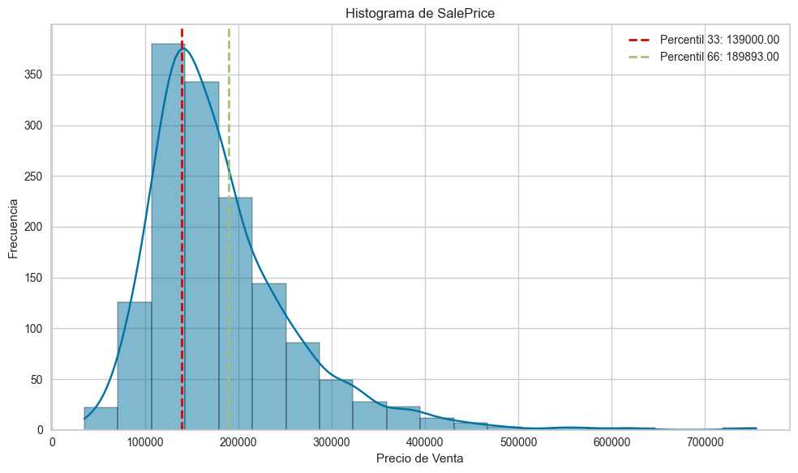

```python
from matplotlib.pyplot import axes

y_column = 'SalePrice'

# Crear los subgráficos (si es necesario)
fig, axes = plt.subplots(1, 1, figsize=(10, 6))  # Aquí puedes ajustar la cantidad de subgráficos

# Crear el histograma con Seaborn
sns.histplot(datos_limpiados2[y_column], bins=20, kde=True, ax=axes)

# Agregar las líneas verticales en los percentiles
axes.axvline(p33, color='r', linestyle='dashed', linewidth=2, label=f'Percentil 33: {p33:.2f}')
axes.axvline(p66, color='g', linestyle='dashed', linewidth=2, label=f'Percentil 66: {p66:.2f}')

# Título y etiquetas
axes.set_title(f'Histograma de {y_column}')
axes.set_xlabel('Precio de Venta')
axes.set_ylabel('Frecuencia')

# Mostrar la leyenda
axes.legend()

# Ajustar el diseño y mostrar el gráfico
plt.tight_layout()
plt.show()
```

Para generar la nueva variable categorica se utilizaron los percentiles sobrela variable SalePrice para asegurar que los precios de venta estuviera distribuidos de manera uniforme entre las 3 categorias que esta nueva variable tiene

# Arbol de clasificacion para la variable PriceType

```python
datos_limpiados2['PriceType'] = datos_limpiados2['PriceType'].astype('category')
print(datos_limpiados2['PriceType'])
```

```
0             Caras
1       Intermedias
2             Caras
3       Intermedias
4             Caras
           ...
1455    Intermedias
1456          Caras
1457          Caras
1458    Intermedias
1459    Intermedias
Name: PriceType, Length: 1460, dtype: category
Categories (3, object): ['Caras', 'Economicas', 'Intermedias']
```

```python
import random


y = datos_limpiados2.pop("PriceType") #La variable respuesta
pventa = datos_limpiados2.pop('SalePrice') #Remover saleprice para entrenar el modelo
X = datos_limpiados2 #El resto de los datos

random.seed(123)
```

```python
#X_train, X_test,y_train, y_test = train_test_split(X, y,test_size=0.3,train_size=0.7)

#Se guardaron en un archivo joblib para que estos no cambien cada vez que se corre el programa

X_train, X_test, y_train, y_test = load('train_test_data.joblib')
```

70% train y 30% test

```python
arbol = DecisionTreeClassifier(criterion="gini", max_depth=4, random_state=42)
arbol = arbol.fit(X_train, y_train)

# Hacer predicciones
y_pred = arbol.predict(X_test)

# Evaluar precisión
accuracy = accuracy_score(y_test, y_pred)
print(f"Precisión del modelo: {accuracy:.2f}")

# Reporte de clasificación
print(classification_report(y_test, y_pred))

confusion_matrix(y_test, y_pred)
```

```
Precisión del modelo: 0.72
              precision    recall  f1-score   support

       Caras       0.70      0.87      0.77       143
  Economicas       0.76      0.80      0.78       150
 Intermedias       0.69      0.48      0.57       145

    accuracy                           0.72       438
   macro avg       0.71      0.72      0.71       438
weighted avg       0.71      0.72      0.71       438
```

```
array([[124,  10,   9],
       [  7, 120,  23],
       [ 47,  28,  70]])
```

- El arbol describe las 3 categorias con un nivel similar de precision sin embargo el recall de la categoria Intermedias es considerablemente bajo lo cual indica que del total de casos verdaderos mas de la mitad fueron falsos negativos mientras que en los otros 2 casos esto no fue el caso. Esto nos indica que las caracteristicas que definen a las Intermedias no son tan caracteristicas comparado con las caracteristicas de las otras categorias.

```
[Text(0.5, 0.9, 'OverallQual <= 6.5\ngini = 0.666\nsamples = 1021\nvalue = [354, 333, 334]\nclass = Economicas'),
```

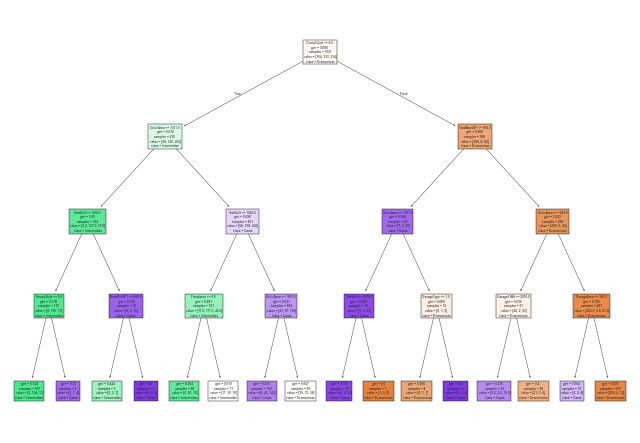

```python
tree.plot_tree(arbol,feature_names=datos_limpiados2.columns,
               class_names=['Economicas','Intermedias','Caras'],filled=True )
```